# The way American people’s attitude toward immigration and China relate to each other and who they vote as their president in 2016

Henan Xu UNI:hx2274

# 1. Introduction

The United States of America has an endured history of a diverse population. In 2018, there were almost 90 million immigrants and U.S.-born children of immigrants in the United States, accounting for 28% of the overall U.S. population. Immigration has always been a central topic in various aspects of the life of American people, including their culture, way of living and of course their political inclinations. In the meantime, China’s rise in recent decades has also been rather controversial for the Americans. Therefore, this study, which makes use of the 2016 ANES Time Series Study data, is aimed to explore how the American’s stance on immigration and China problems relate to each other and their voting in the 2016 Election. Specifically, this study tries to provide answers to the following questions: 1. How are the Americans’ opinions about immigration related to how likely they think immigrants take away jobs?

2. How are the Americans’ attitudes toward immigration and China related?
3. Do the Americans’ stands on immigration result in a specific pattern regarding who they vote for presidency?
4. Do the Americans’ stands on China result in a specific pattern regarding who they vote for presidency?

# 2. Load Packages for Data Processing

# 3. Import raw ANES data

```r
library(haven)
anes_dat <-
    read_sav("D:/Fall2020-Project1-jackxu1998/data/anes_timeseries_2016.sav")
```

# 4 Inspect variables of interest

## 4.1 “V162157: What should immigration levels be”

This is a post-election question raised to the respondent regarding their opinion about the current level of immigration permitted by the government. The question is formulated as follows: “Do you think the number of immigrants from foreign countries who are permitted to come to the United States to live should be [increased a lot, increased a little, left the same as it is now, decreased a little, or decreased a lot / decreased a lot, decreased a little, left the same as it is now, increased a little, or increased a lot]?” The response to this question has five classes: 1. Increased a lot 2. Increased a little 3. Left the same as it is now 4. Decreased a little 5. Decreased a lot Also, there are classes -6 to -9, indicating no response is obtained for this question.

We first get rid of the missing values, namely, rows in which variable *V162157* takes values {-6, -7, -8, -9}.

```r
df1 <- anes_dat[-which((anes_dat$V162157 %in% -6:-9)), ]
```

We then plot a pie chart to see the percentage of each opinion. Note that respondents who answer 1 hold the most positive attitude toward immigration whereas people who answer 5 are the most negative.

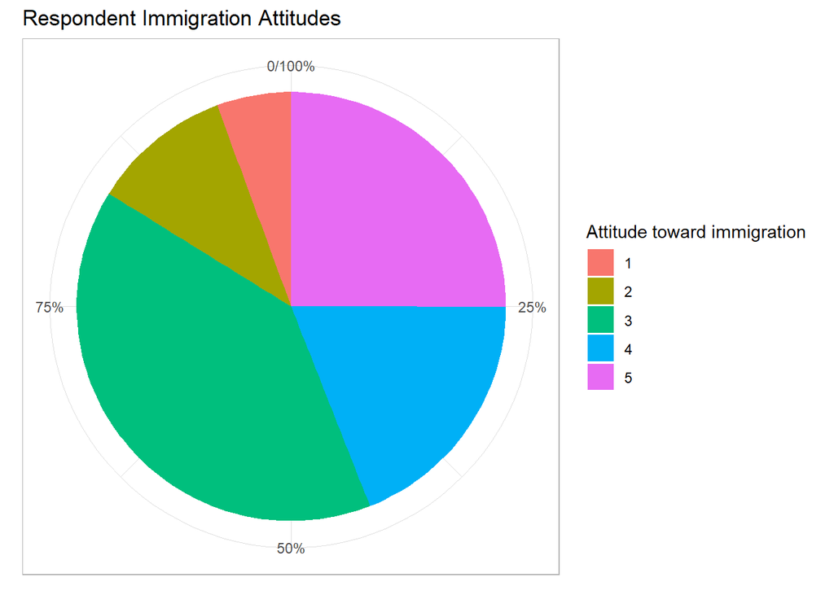

```r
pie.immi <- ggplot(df1, aes(x = factor(1),
                            fill = factor(V162157))) +
  geom_bar(stat = "count") +
  scale_y_continuous(breaks = seq(0, length(df1$V162157),
                                  length(df1$V162157)/4),
                     labels = c("0", "25%", "50%", "75%", "100%")) +
  coord_polar(theta = "y") +
  theme_light() +
  theme(axis.text.y = element_blank(),
      axis.title.y = element_blank(),
      axis.ticks.y = element_blank(),
      axis.title.x = element_blank()) +
  labs(fill = "Attitude toward immigration",
       title = "Respondent Immigration Attitudes")


pie.immi
```

It can be observed that people with a neutral attitude toward the current immigration policy take the most proportion of approximately 40%. Negative (both slightly and heavily) attitudes are more prevalent than positive ones.

We then take a look the number of respondents with different attitudes:

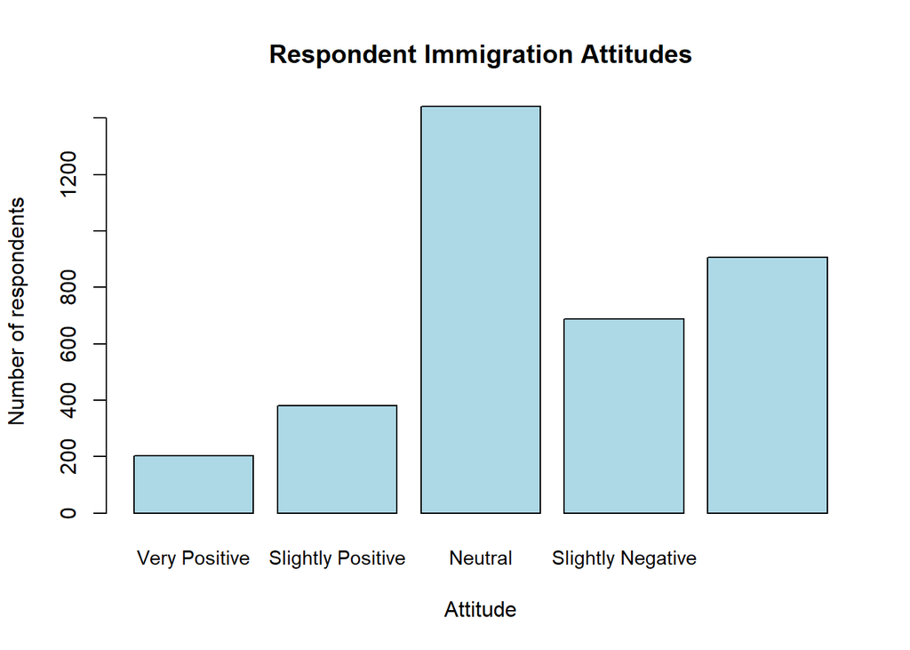

```r
attitudes = c("Very Positive",
                "Slightly Positive",
                "Neutral",
                "Slightly Negative",
                "Very Negative")

barplot(table(df1$V162157), names.arg = attitudes,
        col = "lightblue",
        cex.names=0.9,
        main = "Respondent Immigration Attitudes",
        xlab = "Attitude",
        ylab = "Number of respondents")
```

The Americans’ attitudes toward immigration demonstrate obvious negative skewness, in the way that there are significantly more people with negative attitudes on the right than on the left.

## 4.2 “V162158: How likely immigration will take away jobs”

In variable *V162158*, the respondents are asked for their opinions about whether immigration will take away jobs. The question is formulated as follows: “How likely is it that recent immigration levels will take jobs away from people already here – [extremely likely, very likely, somewhat likely, or not at all likely / not at all likely, somewhat likely, very likely, or extremely likely]?” The response to this question has four classes: 1. Extremely likely 2. Very likely 3. Somewhat likely 4. Not at all likely Also, there are classes -6 to -9, indicating no response is obtained for this question.

Again, we first get rid of the missing values, namely, rows in which variable *V162158* takes values {-6, -7, -8, -9}.

```r
df2 <- anes_dat[-which((anes_dat$V162158 %in% -6:-9)), ]
```

We plot a bar graph showing the number of respondents with each answer.

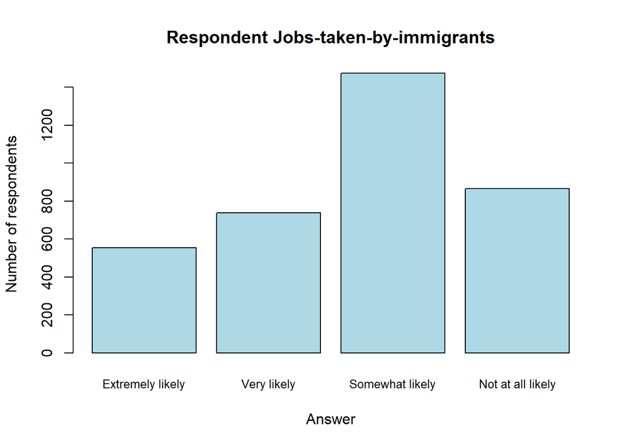

```r
jobs = c("Extremely likely",
         "Very likely",
         "Somewhat likely",
         "Not at all likely")

barplot(table(df2$V162158), names.arg = jobs,
        col = "lightblue",
        cex.names=0.8,
        main="Respondent Jobs-taken-by-immigrants",
        xlab = "Answer",
        ylab = "Number of respondents")
```

## 4.3 “V162159: China military threat”

In variable *V162159*, the respondents are asked how much of a thread they rate China. The question is formulated as follows: “Do you think China’s military is [a major threat to the security of the United States, a minor threat, or not a threat / not a threat, a minor threat, or a major threat to the security of the United States]?” The response to this question has three classes: 1. Major threat 2. Minor threat 3. Not a threat Also, there are classes -6 to -9, indicating no response is obtained for this question.

Again, we first get rid of the missing values, namely, rows in which variable *V162159* takes values {-6, -7, -8, -9}.

```r
df3 <- anes_dat[-which((anes_dat$V162159 %in% -6:-9)), ]
```

We plot a bar graph showing the number of respondents with each answer.

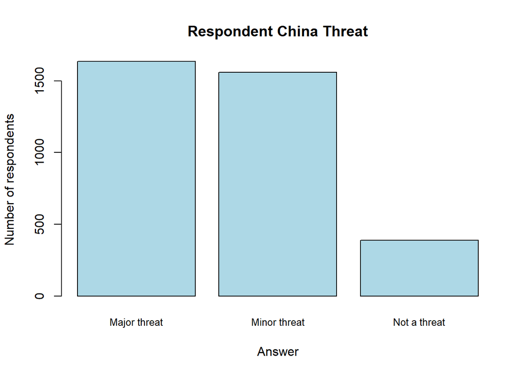

```r
answers = c("Major threat",
         "Minor threat",
         "Not a threat")

barplot(table(df3$V162159), names.arg = answers,
        col = "lightblue",
        cex.names=0.8,
        main="Respondent China Threat",
        xlab = "Answer",
        ylab = "Number of respondents")
```

## 4.4 “V162034a: For whom did R vote for President”

In variable *V162034a*, the respondents are asked who they voted for President. The question is formulated as follows: “Who did you vote for? [Hillary Clinton, Donald Trump / Donald Trump, Hillary Clinton], Gary Johnson, Jill Stein, or someone else?” The response to this question has five classes: 1. Hillary Clinton 2. Donald Trump 3. Gary Johnson 4. Jill Stein 5. Other candidate SPECIFY Also, there are classes -6 to -9 and -1, indicating no response is obtained for this question. Classes 7 and 9 are ignored since they are too small.

Again, we first get rid of the missing and ignored values, namely, rows in which variable *V162034a* takes values {-6, -7, -8, -9, -1, 7, 9}.

```r
df4 <- anes_dat[-which((anes_dat$V162034a %in% c(-6, -7, -8, -9, -1, 7, 9))), ]
```

We plot a bar graph showing the number of respondents with each candidate.

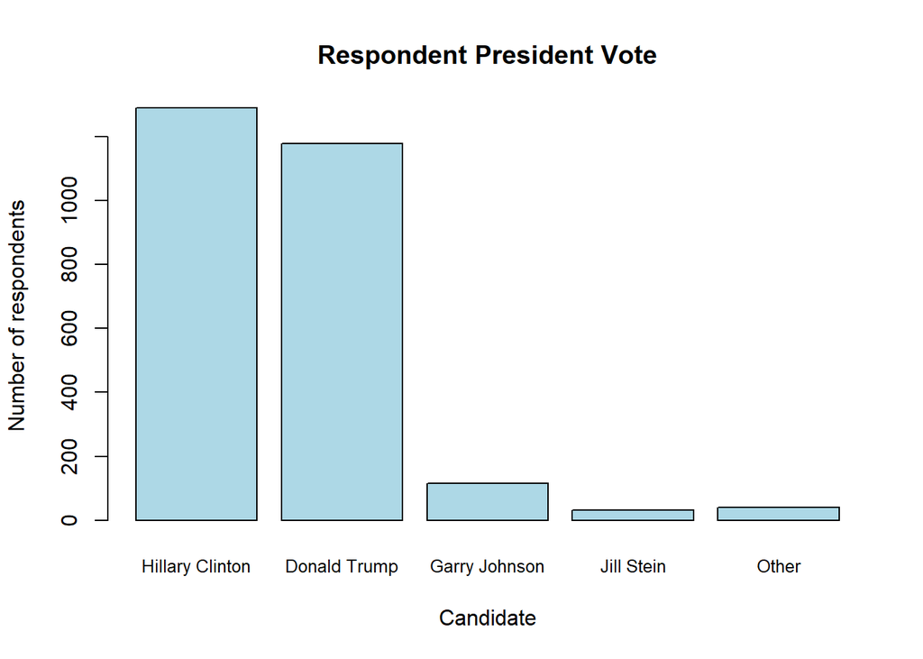

```r
can = c("Hillary Clinton",
        "Donald Trump",
        "Garry Johnson",
        "Jill Stein",
        "Other")

barplot(table(df4$V162034a), names.arg = can,
        col = "lightblue",
        cex.names=0.8,
        main="Respondent President Vote",
        xlab = "Candidate",
        ylab = "Number of respondents")
```

# 5. Process and analyze data

## 5.1 Process variables for analysis

First, four revlavant variables are selected and the data is filtered for missing and ignored values. The resulting data is saved to the `output` folder.

```r
data_use = anes_dat%>%
  filter(!V162157 %in% -6:-9) %>%
  filter(!V162158 %in% -6:-9) %>%
  filter(!V162159 %in% -6:-9) %>%
  filter(!V162034a %in% c(-6, -7, -8, -9, -1, 7, 9)) %>%
  mutate(
    immi = factor(V162157),
    jobs_taken = factor(V162158),
    china = factor(V162159),
    president = factor(V162034a)) %>%
  select(immi, jobs_taken, china, president)

save(data_use, file="D:/Fall2020-Project1-jackxu1998/output/data_use.RData")
```

## 5.2 “How are the Americans’ opinions about immigration related to how likely they think immigrants take away jobs?”

It is intuitive to think that the more likely the respondent finds employment opportunities are going to be taken away by immigrants, the more negative he/she is toward the immigration policy. We find out by grouping the respondents by their perceived danger of jobs being taken away.

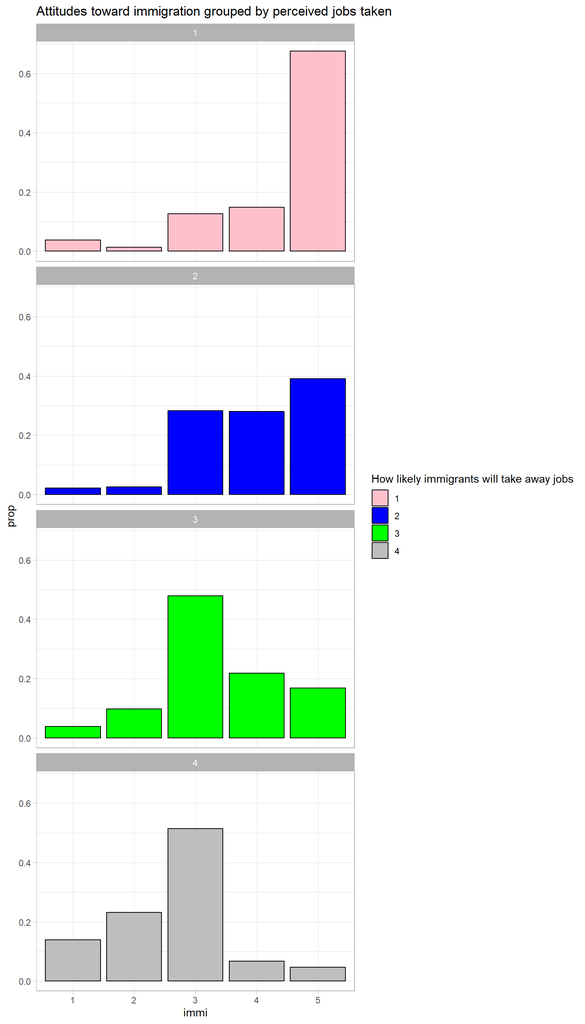

```r
jobs_immi = data_use %>%
  group_by(jobs_taken)%>%
  count(immi)%>%
  mutate(
    prop = n/sum(n)
  )

ggplot(jobs_immi,
       aes(x=immi, y=prop, fill = jobs_taken)) +
  geom_bar(stat="identity", colour="black")+
  scale_fill_manual(values=c("pink", "blue", "green", "grey"))+
  facet_wrap(~jobs_taken, ncol=1) +
  theme_light()+
  labs(fill = "How likely immigrants will take away jobs",
    title="Attitudes toward immigration grouped by perceived jobs taken")
```

The result conforms quite well with our intuition. It is obvious from the grouped bar plots that there are significantly more people, in terms of proportion, being negative on immigration in situations where these people believe it is relatively probable that their employment opportunities will be shared by immigrants. We can conclude that if one believes that immigrants will take away jobs, he/she is highly likely negative on immigration. Moreover, we do observe that even among groups who are less obsessed with the jobs-taken-away theory, there are not many active supporters for immigration and most people hold a neutral stand.

## 5.3 “How are the Americans’ attitudes toward immigration and China related?”

It makes sense to deem the attitudes toward immigration and China related, with the theory being people who are negative on immigration are generally less open and potentially more hostile and should therefore regard China as a major threat. We find out by grouping the respondents by their attitudes toward immigration.

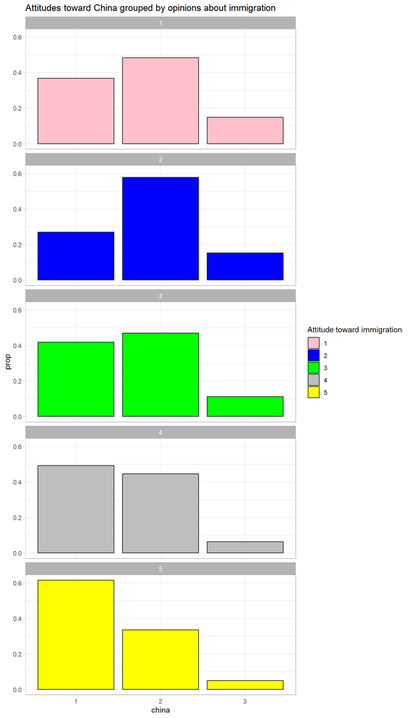

```r
immi_china = data_use %>%
  group_by(immi)%>%
  count(china)%>%
  mutate(
    prop = n/sum(n)
  )

ggplot(immi_china,
       aes(x=china, y=prop, fill = immi)) +
  geom_bar(stat="identity", colour="black")+
  scale_fill_manual(values=c("pink", "blue", "green", "grey", "yellow"))+
  facet_wrap(~immi, ncol=1) +
  theme_light()+
  labs(fill = "Attitude toward immigration",
    title="Attitudes toward China grouped by opinions about immigration")
```

The pattern is observable here with an increasingly higher proportion of respondents deeming China a major threat as we go toward the negative direction of immigration attitudes. The only exception is the proportion seeing China as a major threat falls going from 1 to 2 in immigration attitude, though it is coupled with an increase in the proportion of seeing China as a minor threat. Overall, the takeaway we have here is that it is a mainstream mindset among the Americans to regard China as a potential threat, major or not. Very few people believe China is not a threat.

## 5.4 “Do the Americans’ stands on immigration result in a specific pattern regarding who they vote for presidency?”

Given what President Trump has been saying and doing since his inauguration, it is natural to think that people who voted for him back in 2016 should not be too happy with an overly loose immigration policy. It is therefore hypothesized that people with a more negative attitude toward immigration are more likely to vote for Donald Trump instead of Hillary Clinton. We find out by grouping the respondents by their attitudes toward immigration.

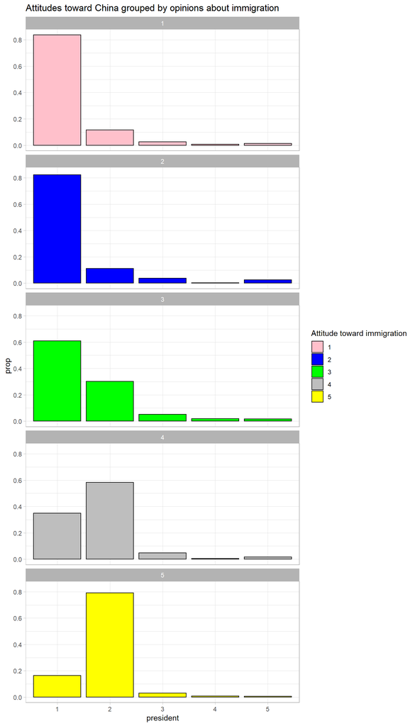

```r
immi_president = data_use %>%
  group_by(immi)%>%
  count(president)%>%
  mutate(
    prop = n/sum(n)
  )

ggplot(immi_president,
       aes(x=president, y=prop, fill = immi)) +
  geom_bar(stat="identity", colour="black")+
  scale_fill_manual(values=c("pink", "blue", "green", "grey", "yellow"))+
  facet_wrap(~immi, ncol=1) +
  theme_light()+
  labs(fill = "Attitude toward immigration",
    title="Attitudes toward China grouped by opinions about immigration")
```

The trend is fairly conspicuous that with the immigration attitude moves towards the negative end, the proportion of respondents who voted for Donald Trump grows significantly whereas that of Hillary Clinton’s supporters drops. It is also worth noticing that the neutral stand on immigration policy acts as a evident watershed here, with Clinton having more supporters in attitudes above neutral and Trump having more supporters in attitudes below.

## 5.5 “Do the Americans’ stands on China result in a specific pattern regarding who they vote for presidency?”

Given what President Trump has been saying and doing since his inauguration, it is natural to think that people who voted for him back in 2016 should not be too friendly to China. It is therefore hypothesized that people with a more hostile attitude toward China are more likely to vote for Donald Trump instead of Hillary Clinton. We find out by grouping the respondents by their attitudes toward China.

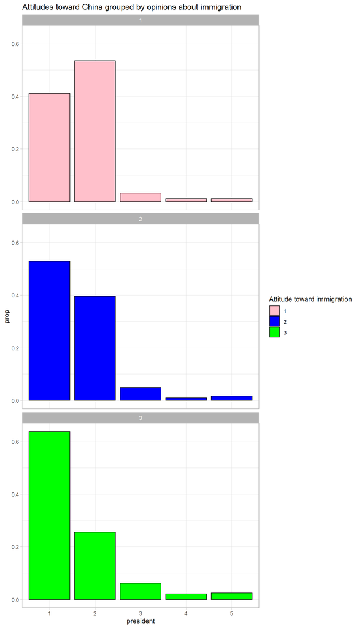

```r
china_president = data_use %>%
  group_by(china)%>%
  count(president)%>%
  mutate(
    prop = n/sum(n)
  )

ggplot(china_president,
       aes(x=president, y=prop, fill = china)) +
  geom_bar(stat="identity", colour="black")+
  scale_fill_manual(values=c("pink", "blue", "green"))+
  facet_wrap(~china, ncol=1) +
  theme_light()+
  labs(fill = "Attitude toward immigration",
    title="Attitudes toward China grouped by opinions about immigration")
```

The pattern is rather overt here, with fewer and fewer people, in terms of proportions, voting for Donald Trump, as the attitude goes from “seeing as a major threat” to “not seeing as a threat”. It is also worth noticing that Trump only had more supporters among people who deem China a major threat, whereas Clinton earned more support among people with both less radical attitudes.

# 6. Conclusion

1. Perceiving more danger in losing jobs to immigrants does worsen one’s attitude toward immigration. Even among the most optimistic people in terms of immigration employment problems, most people take no better than a neutral stance on the immigration policy.
2. Being less open about the immigration policy does indicate a higher chance of deeming China as a threat (both major and minor, in general). The prevalence of the idea that China is, in certain degree, a military threat to the U.S. is evident.
3. People with more negative attitude toward immigration are more likely to vote for Donald Trump as opposed to Hillary Clinton. The neutral stand on immigration appears to be a watershed, with Clinton having more supporters in attitudes above neutral and Trump having more supporters in attitudes below.
4. The more one sees China as a threat, the more likely he/she will vote for Donald Trump instead of Hillary Clinton. Trump won the election in the end even if he only had more supporters among people who deem China a major threat, whereas Clinton earned more support among people with both less radical attitudes.